# Handling Missing Data in Health Science Research

Day 1 - Part I

2022-06-21

# About this workshop

## Instructor

Aya Mitani, PhD, MPH  
Assistant Professor  
Division of Biostatistics  
Dalla Lana School of Public Health  
[Website](https://www.ayamitani.com/)

## Student Assistant

Mei Dong, MSc  
PhD student in Biostatistics  
Dalla Lana School of Public Health  
[Website](https://meidongstat.github.io/)

## Overview

### Day I (2022 June 21 1-3p)

- Introduction
  - Missing data in health research
  - Missing data type
  - Missing data mechanism
- Understanding missingness in data
  - Visual inspection
  - Can it be ignored?
- Missing data in cross-sectional data
  - Single-level multiple imputation (MI)
  - MI of interaction variables

### Day II (2022 June 23 1-3p)

- Missing data in longitudinal data
  - IPW for drop-out in longitudinal data
  - Multiple imputation for multilevel data
- Methods for nonignorable missing data
- Consideration for fairness in missing data imputation

## Housekeeping

- The workshop will **not** be recorded
- We will have a **10-minute break** in the middle of each session
- Ask questions!
  - Feel free to interrupt me by **raising your hand**
  - Put questions in the **chat** (Mei will field most of the questions)
  - Wait until the **end of each session** (I will stick around for a few minutes after 3p)

# Missing data in health research

- It is **very** common for sets of quantitative data to be incomplete
  - i.e. Not all **planned** observations are actually made
- This is especially true when studies are conducted on **human** subjects, e.g.,
  - Epidemiologic studies
  - Clinical trials
  - Sample surveys
- Missing data can lead to **bias** and **lack of precision** in the analyses
- The default method is complete-case analysis or listwise deletion
  - Observations with at least one variable missing is deleted from the analysis

[figure not shown]

## Reasons for missing data

- Item nonresponse
  - Respondent skips a question because they don’t want to provide an answer
- Unit nonresponse
  - Refusal to complete the survey (see above cartoon)
- Data entry or coding error
  - Frequently occurs in administrative data
- Loss to follow-up
  - Informative or non-informative censoring
- By design
  - Bad survey design (unintentional)
  - Sampling (intentional)
- Many more

> Obviously the best way to treat missing data is not to have them.  
> [Orchard and Woodbury (1972, p.697)]

## Be explicit about missing data

- Researchers tend to downplay the issue of missing data
- Best practices when dealing with missing data
  - The presence of missing data should be explicitly stated in the text
  - If using default methods (listwise deletion or complete-case analysis), then mention it
  - Make sure all your tables have the same sample sizes
  - Use model-based missing data methods
- Not being explicit about missing data negatively affects the **reproducibility**, **replicability**, and **reliability** of your research

# Example data: The Skin Cancer Prevention Study

The data are from a randomized, double-blind, placebo-controlled clinical trial of beta-carotene to prevent non-melanoma skin cancer in high risk subjects. Subjects were randomized to either receive placebo or 50mg of beta-carotene per day for 5 years. Subjects were examined once a year and biopsied if a cancer was suspected to determine the number of new skin cancers occurring since the last exam. The outcome variable is a count of the number of new skin cancers per year. The dataset contains 1683 observations. (https://pubmed.ncbi.nlm.nih.gov/2666024/)

| Variable | Category | Explanation |
| --- | --- | --- |
| `ID` | categorical | ID of participant |
| `center` | categorical | study center (1-4) |
| `age` | numeric | age (in years) at baseline |
| `skin` | binary | skin type, 1=burns, 0=otherwise |
| `gender` | categorical | 1=male, 0=female |
| `exposure` | count | number of previous skin cancers |
| `treatment` | categorical | 1=beta-carotene, 0=placebo |
| `year` | numeric | year of follow-up |
| `Y` | count | number of new skin cancers per year |

```r
skin <- read.table("skin_data.txt", header = TRUE)
head(skin, 10)
```

```
##        ID center age skin gender exposure Y treatment year
## 1  100034      1  51    1      1        4 0         0    1
## 2  100034      1  51    1      1        4 1         0    2
## 3  100034      1  51    1      1        4 1         0    3
## 4  100034      1  51    1      1        4 1         0    4
## 5  100034      1  51    1      1        4 0         0    5
## 6  100045      1  68    1      0        2 0         0    1
## 7  100045      1  68    1      0        2 0         0    2
## 8  100045      1  68    1      0        2 0         0    3
## 9  100045      1  68    1      0        2 0         0    4
## 10 100045      1  68    1      0        2 0         0    5
```

```r
tail(skin, 10)
```

```
##          ID center age skin gender exposure Y treatment year
## 7072 420645      4  67    1      0        1 0         1    3
## 7073 420656      4  41    1      1        1 0         1    1
## 7074 420656      4  41    1      1        1 0         1    2
## 7075 420656      4  41    1      1        1 0         1    3
## 7076 420678      4  66    0      1        1 0         1    1
## 7077 420678      4  66    0      1        1 0         1    2
## 7078 420678      4  66    0      1        1 1         1    3
## 7079 420689      4  62    0      0        1 0         1    1
## 7080 420689      4  62    0      0        1 0         1    2
## 7081 420689      4  62    0      0        1 0         1    3
```

# Missing data in cross-sectional data

## Notation

- $\boldsymbol{Y}$ is the $n\times p$ matrix containing the data values on $p$ variables for $n$ people
- $\boldsymbol{R}$ is the $n\times p$ matrix containing the response indicator ($0$ or $1$)
  - If $Y_{ij}$ is observed then $R_{ij}=1$
  - If $Y_{ij}$ is not observed then $R_{ij}=0$

For example, if we have a data set containing 5 people and 4 variables that look like

```
##   id v1 v2 v3 v4
## 1  1 50  0  5  1
## 2  2 65  0 NA  0
## 3  3 48  0 NA NA
## 4  4 45  1  9  1
## 5  5 51  1  2 NA
```

- Further $\boldsymbol{Y}=(\boldsymbol{Y}_{\text{obs}}, \boldsymbol{Y}_{\text{mis}})$ contain the hypothetically complete data, where
  - $\boldsymbol{Y}_{\text{obs}}$ is the set of observed data
  - $\boldsymbol{Y}_{\text{mis}}$ has real values, but the values themselves are masked from us
  - Missingness indicators hid the true values that are **meaningful for analysis**

## Missing data mechanism

- A hierarchy of **three** different types of missing data mechanisms can be distinguished by considering how $\boldsymbol{R}$ is related to $\boldsymbol{Y}=(\boldsymbol{Y}_{\text{obs}}, \boldsymbol{Y}_{\text{mis}})$

**Missing completely at random (MCAR)**

- Probability that responses are missing does not depend on $\boldsymbol{Y}_{\text{obs}}$ or $\boldsymbol{Y}_{\text{mis}}$
- $\Pr(R=0|Y_{\text{obs}}, Y_{\text{mis}}) = \Pr(R=0)$
- The observed values can be thought of as a **random sample** of the full data

**Missing at random (MAR)**

- Probability that responses are missing may depend on observed information, $\boldsymbol{Y}_{\text{obs}}$
- $\Pr(R=0|Y_{\text{obs}}, Y_{\text{mis}}) = \Pr(R=0|Y_{\text{obs}})$

**Missing not at random (MNAR)**

- Probability that responses are missing depends on the set of observed information, $\boldsymbol{Y}_{\text{obs}}$, and the values that should have been obtained, $\boldsymbol{Y}_{\text{mis}}$
- $\Pr(R=0|Y_{\text{obs}}, Y_{\text{mis}})$ does not simplify

[figure not shown]

Photo courtesy of Larry Dong (PhD student in Biostatistics)

- MCAR and MAR are often referred to as **ignorable** mechanisms
- MNAR is referred to as **nonignorable** mechanism
- Several tests exist to distinguish between MCAR and MAR, but they are not widely used and their practical value is unclear
  - [Enders (2010, p. 17-21)](https://www.guilford.com/books/Applied-Missing-Data-Analysis/Craig-Enders/9781606236390) evaluates two procedures
- It is not possible to test MAR versus MNAR because the information that is needed for such a test is missing!

## Year 1 data of skin cancer study

```r
skinbl <- read.table("skin_FULL.txt", header = TRUE)
head(skinbl, 10)
```

```
##        ID center age skin gender exposure Y treatment year
## 1  100034      1  51    1      1        4 0         0    1
## 2  100045      1  68    1      0        2 0         0    1
## 3  100056      1  58    1      0        7 1         0    1
## 4  100067      1  53    1      1        3 0         0    1
## 5  100102      1  55    0      0        2 0         0    1
## 6  100113      1  59    1      1       10 0         0    1
## 7  100124      1  56    0      1        5 0         0    1
## 8  100146      1  59    0      0        2 1         0    1
## 9  100214      1  64    1      1        2 0         0    1
## 10 100236      1  69    0      1        1 1         0    1
```

```r
tail(skinbl, 10)
```

```
##          ID center age skin gender exposure Y treatment year
## 1674 420410      4  63    1      1       11 0         1    1
## 1675 420476      4  63    1      0        1 0         1    1
## 1676 420487      4  38    0      1        1 0         1    1
## 1677 420511      4  40    1      1        1 0         1    1
## 1678 420555      4  47    0      1        2 0         1    1
## 1679 420634      4  64    0      0        3 1         1    1
## 1680 420645      4  67    1      0        1 0         1    1
## 1681 420656      4  41    1      1        1 0         1    1
## 1682 420678      4  66    0      1        1 0         1    1
## 1683 420689      4  62    0      0        1 0         1    1
```

- For this workshop, we generated **three** different cross-sectional data sets
- The variables `age` and `skin` were simulated to be MCAR, MAR, and MNAR for each data set

[output not shown]

## Missing data visualization

- Many packages in R are available to describe the prevalence and pattern of missing data
- We will go over three packages

```r
library(naniar)
library(VIM)
library(finalfit)
```

### Heatplot of missingness across the entire data frame

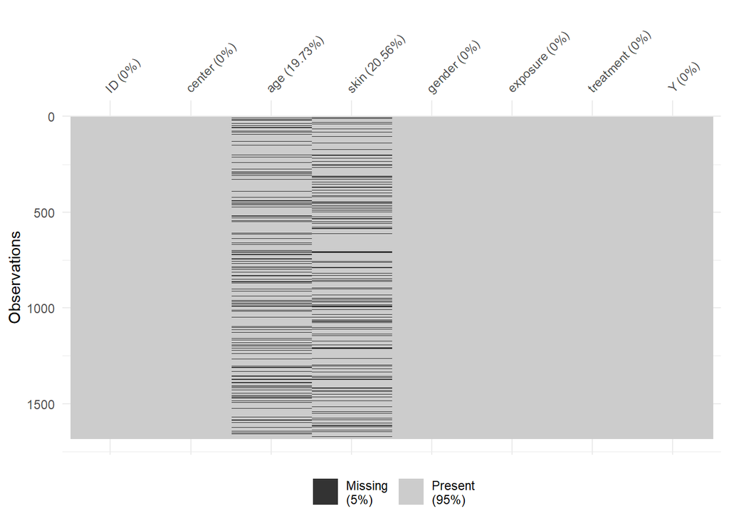

```r
naniar::vis_miss(skin_mcar)
```

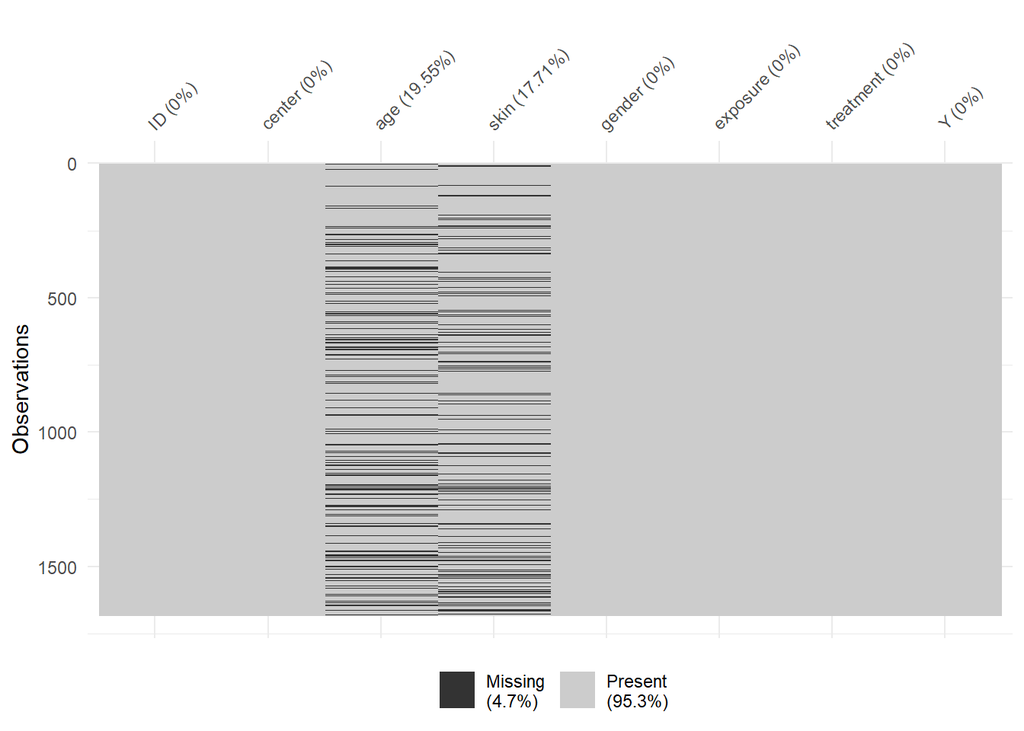

```r
naniar::vis_miss(skin_mar)
```

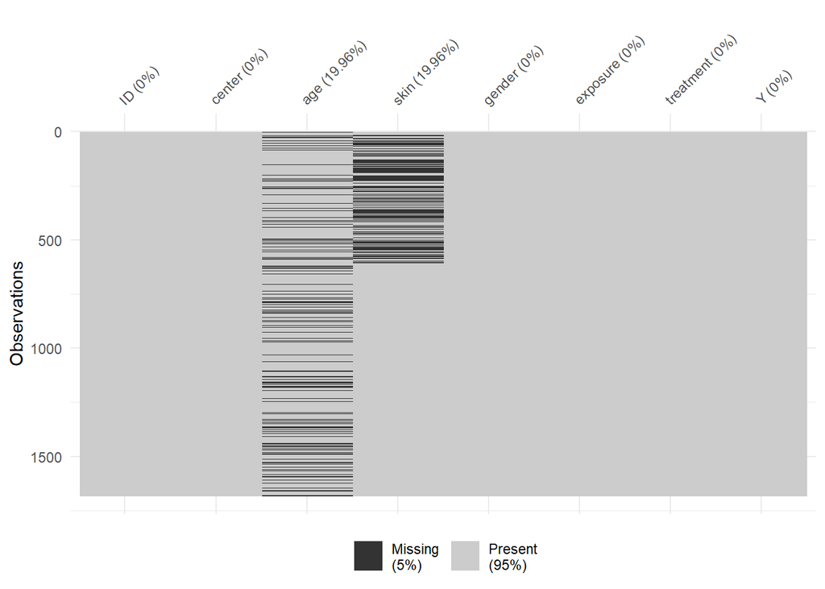

```r
naniar::vis_miss(skin_mnar)
```

### Lollipop plot of percentage of missingness for each variable

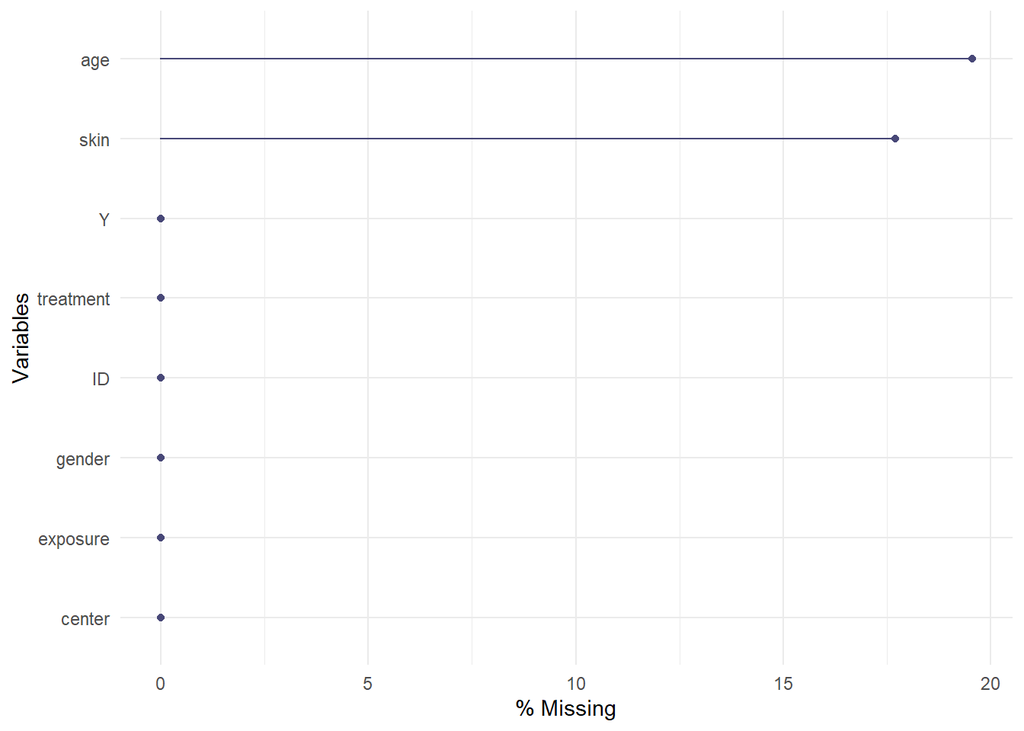

```r
naniar::gg_miss_var(skin_mar, show_pct = TRUE)
```

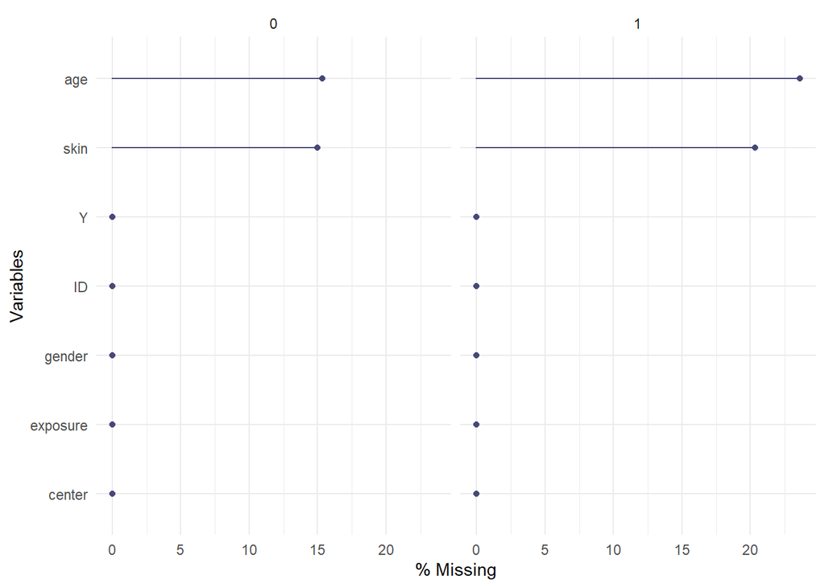

```r
# Stratified by treatment
naniar::gg_miss_var(skin_mar, show_pct = TRUE, facet = treatment)
```

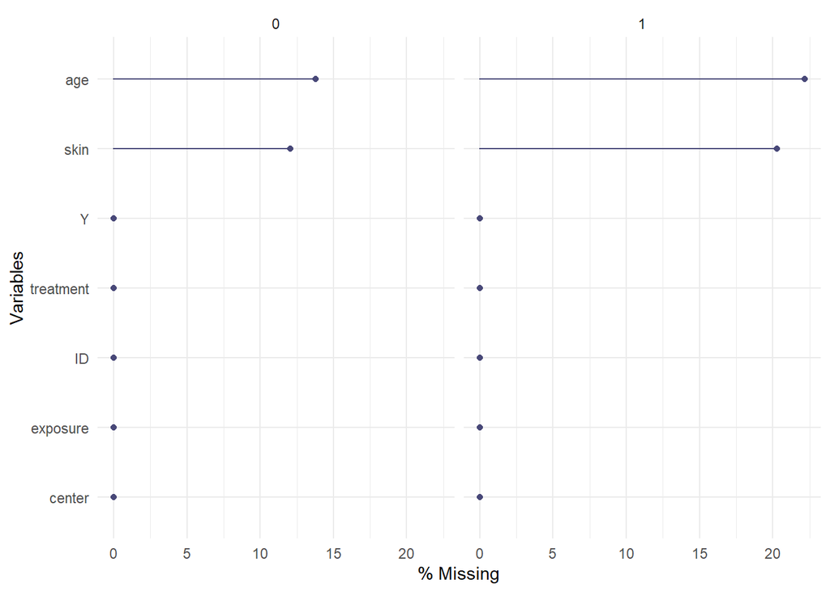

```r
# Stratified by gender
naniar::gg_miss_var(skin_mar, show_pct = TRUE, facet = gender)
```

### Aggregation plot

The left column is a bar chart of missingness for each variable while the right column depicts how often each **combination** of missing occurs.

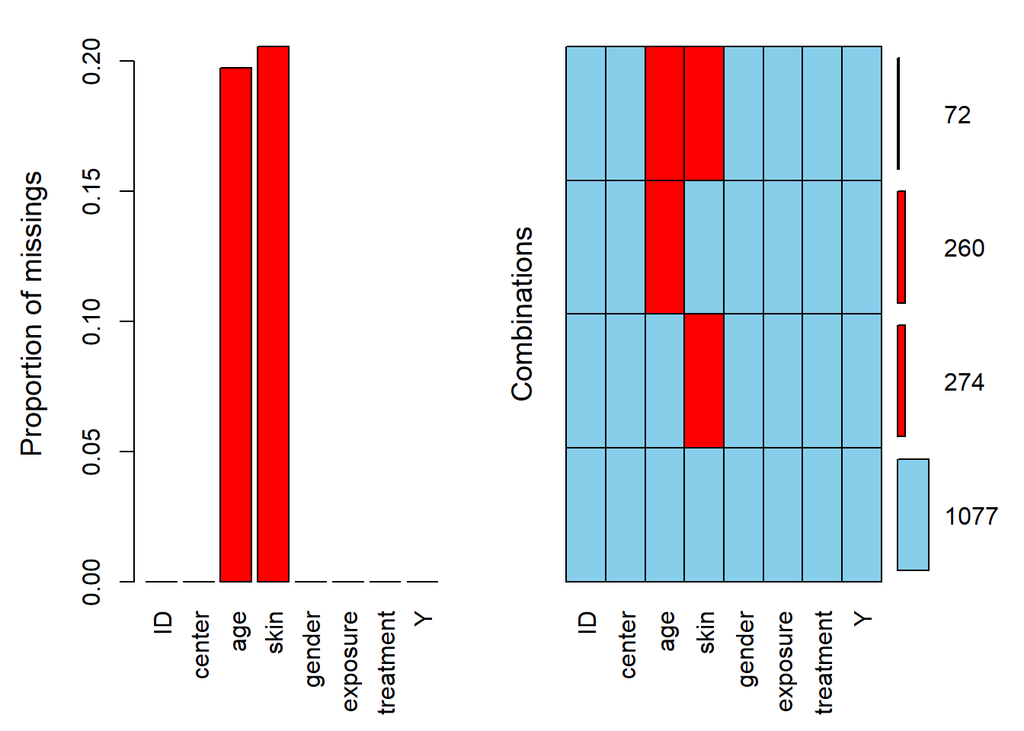

```r
VIM::aggr(skin_mcar, numbers = TRUE, prop = c(TRUE, FALSE))
```

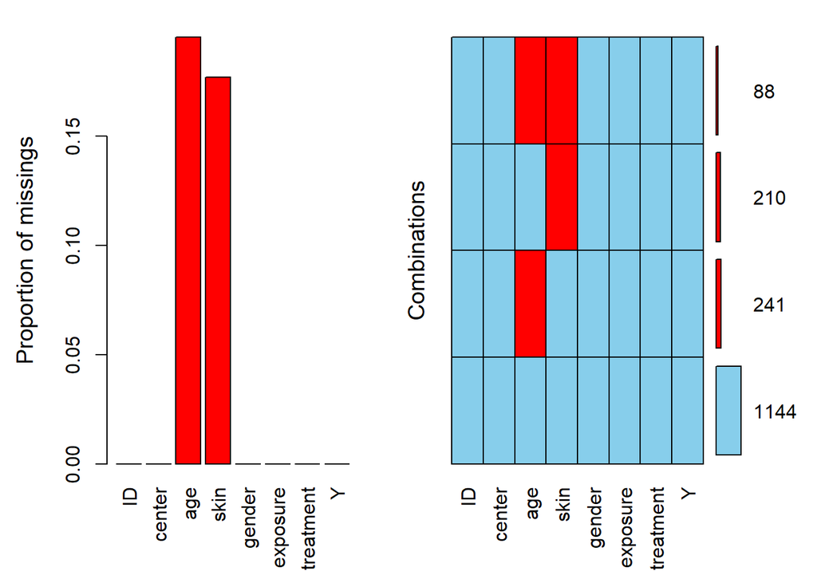

```r
VIM::aggr(skin_mar, numbers = TRUE, prop = c(TRUE, FALSE))
```

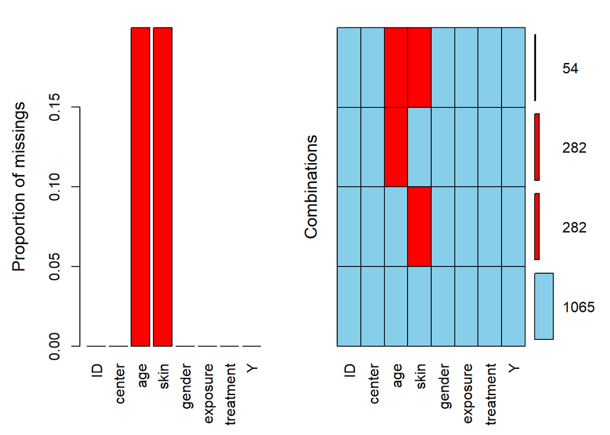

```r
VIM::aggr(skin_mnar, numbers = TRUE, prop = c(TRUE, FALSE))
```

### Missing data matrix

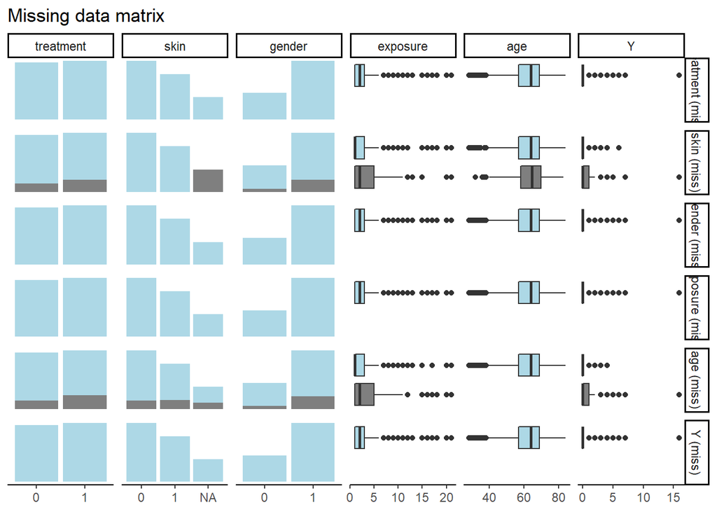

```r
# need to change numeric variables to factor variables
skin_mar[, c("center", "skin", "gender", "treatment")] <- lapply(skin_mar[, c("center", "skin", "gender", "treatment")], factor)
finalfit::missing_pairs(skin_mar, dependent = "treatment",
                        explanatory = c("skin", "gender", "exposure", "age", "Y"))
```

### Descriptive table

We can also describe the prevalence of missingness in a table using `missing_compare()`.

```r
skin_mcar %>%
  finalfit::missing_compare(dependent="age", explanatory=c("skin","gender","exposure","treatment","Y")) %>%
  knitr::kable(row.names=FALSE, align = c("l", "l", "r", "r", "r")) %>%
  kable_styling()
```

| Missing data analysis: age |  | Not missing | Missing | p |
| --- | --- | --- | --- | --- |
| skin | 0 | 590 (81.0) | 138 (19.0) | 0.670 |
|  | 1 | 487 (80.0) | 122 (20.0) |  |
| gender | 0 | 428 (81.8) | 95 (18.2) | 0.310 |
|  | 1 | 923 (79.6) | 237 (20.4) |  |
| exposure | Mean (SD) | 2.8 (3.3) | 3.2 (3.7) | 0.062 |
| treatment | 0 | 668 (80.8) | 159 (19.2) | 0.656 |
|  | 1 | 683 (79.8) | 173 (20.2) |  |
| Y | Mean (SD) | 0.3 (0.7) | 0.3 (1.1) | 0.289 |

```r
skin_mar %>%
  finalfit::missing_compare(dependent="age", explanatory=c("skin","gender","exposure","treatment","Y")) %>%
  knitr::kable(row.names=FALSE, align = c("l", "l", "r", "r", "r")) %>%
  kable_styling()
```

| Missing data analysis: age |  | Not missing | Missing | p |
| --- | --- | --- | --- | --- |
| skin | 0 | 666 (85.3) | 115 (14.7) | 0.004 |
|  | 1 | 478 (79.1) | 126 (20.9) |  |
| gender | 0 | 451 (86.2) | 72 (13.8) | <0.001 |
|  | 1 | 903 (77.8) | 257 (22.2) |  |
| exposure | Mean (SD) | 2.6 (2.9) | 4.2 (4.6) | <0.001 |
| treatment | 0 | 700 (84.6) | 127 (15.4) | <0.001 |
|  | 1 | 654 (76.4) | 202 (23.6) |  |
| Y | Mean (SD) | 0.2 (0.5) | 0.6 (1.5) | <0.001 |

```r
skin_mnar %>%
  finalfit::missing_compare(dependent="age", explanatory=c("skin","gender","exposure","treatment","Y")) %>%
  knitr::kable(row.names=FALSE, align = c("l", "l", "r", "r", "r")) %>%
  kable_styling()
```

| Missing data analysis: age |  | Not missing | Missing | p |
| --- | --- | --- | --- | --- |
| skin | 0 | 445 (76.9) | 134 (23.1) | 0.097 |
|  | 1 | 620 (80.7) | 148 (19.3) |  |
| gender | 0 | 409 (78.2) | 114 (21.8) | 0.231 |
|  | 1 | 938 (80.9) | 222 (19.1) |  |
| exposure | Mean (SD) | 3.0 (3.5) | 2.3 (2.8) | <0.001 |
| treatment | 0 | 663 (80.2) | 164 (19.8) | 0.941 |
|  | 1 | 684 (79.9) | 172 (20.1) |  |
| Y | Mean (SD) | 0.3 (0.9) | 0.2 (0.6) | 0.018 |

**Observations**

- Note that none of these visualization tools were helpful in distinguishing the missing data mechanism (especially between MAR and MNAR)
- For MNAR, missingness relies on some unknown variables or the missing values themselves and we need subject-matter expertise

## Implications of performing complete-case analysis with missing data

- The model of interest is a log-linear model for counts
  $$\log E(Y) = \beta_0 + \beta_1\text{treatment} + \beta_2\text{age} +
  \beta_3\text{gender} + \beta_4\text{exposure} + \beta_5\text{skin}$$
  where $Y$ is the number of new skin cancers in the first year of treatment.
- Note that we are ignoring some assumptions about the model:
  - Zero inflation
  - Overdispersion
  - These are topics for another workshop!

```r
# we convert variables from numeric type to factor type before running the regression
skinbl[, c("center", "skin", "gender", "treatment")] <-
  lapply(skinbl[, c("center", "skin", "gender", "treatment")], factor)
skin_mcar[, c("center", "skin", "gender", "treatment")] <-
  lapply(skin_mcar[, c("center", "skin", "gender", "treatment")], factor)
skin_mnar[, c("center", "skin", "gender", "treatment")] <-
  lapply(skin_mnar[, c("center", "skin", "gender", "treatment")], factor)
```

```r
fullmod <- glm(Y ~ treatment + age + gender + exposure + skin, family = poisson("log"), data = skinbl)
mcarmod <- glm(Y ~ treatment + age + gender + exposure + skin, family = poisson("log"), data = skin_mcar)
marmod <- glm(Y ~ treatment + age + gender + exposure + skin, family = poisson("log"), data = skin_mar)
mnarmod <- glm(Y ~ treatment + age + gender + exposure + skin, family = poisson("log"), data = skin_mnar)

htmlreg(list(fullmod, mcarmod, marmod, mnarmod),
        custom.model.names = c("Full", "MCAR", "MAR", "MNAR"),
        caption = "Comparing results from different missing data mechanisms. Showing estimate (std err).",
        include.loglik = FALSE, include.aic = FALSE, include.bic = FALSE, include.deviance = FALSE)
```

Comparing results from different missing data mechanisms. Showing estimate (std err).

|  | Full | MCAR | MAR | MNAR |
| --- | --- | --- | --- | --- |
| (Intercept) | -3.60*** | -3.85*** | -3.02*** | -4.44*** |
|  | (0.36) | (0.46) | (0.50) | (0.62) |
| treatment1 | 0.06 | 0.07 | 0.06 | 0.42*** |
|  | (0.09) | (0.12) | (0.14) | (0.12) |
| age | 0.02*** | 0.02** | 0.01 | 0.02** |
|  | (0.01) | (0.01) | (0.01) | (0.01) |
| gender1 | 0.47*** | 0.59*** | 0.28 | 0.43** |
|  | (0.12) | (0.15) | (0.16) | (0.14) |
| exposure | 0.13*** | 0.13*** | 0.13*** | 0.12*** |
|  | (0.01) | (0.01) | (0.01) | (0.01) |
| skin1 | 0.36*** | 0.41*** | 0.30* | 0.73*** |
|  | (0.09) | (0.12) | (0.14) | (0.13) |
| Num. obs. | 1683 | 1077 | 1144 | 1065 |

***p < 0.001; **p < 0.01; *p < 0.05

**Observations**

- Coefficient estimates from MCAR are close to Full, but the standard error estimates are larger
- Coefficient estimates from MAR and MNAR are quite different and the standard estimates are larger compared to Full
- Coefficient estimate of `treatment` is much larger in MNAR even though `treatment` was not related to missingness of `age` or `skin`